Lake Name: Crooked Lake

Lake acreage: 105.6

County: ONONDAGA

PWLID: 0602-0090

Waterbody Classification: B

Coordinates: 42.786891,-76.152811

Is this waterbody a public water supply: No

Are there DOH desingated beaches on this waterbody: No

Open Water Indicators

2018 Sampling Results

Seasonal Change

06-09

07-01

07-15

07-28

08-12

08-26

09-17

09-29

Clarity (m)

4.10

3.70

4.95

4.93

3.65

2.70

3.35

2.95

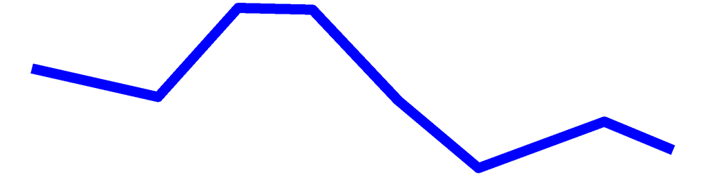

Surface TP (mg/L)

0.01

0.01

0.01

0.01

0.01

0.01

0.01

0.01

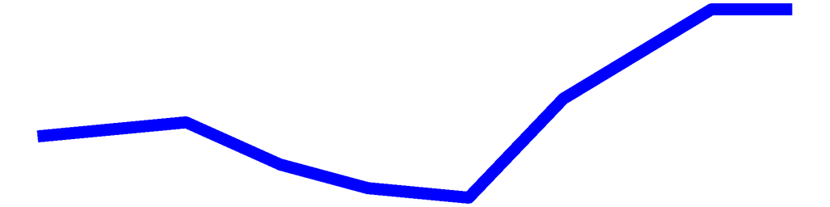

Surface TDP (mg/L)

0.01

0.01

0.01

0.00

0.00

0.00

0.00

0.00

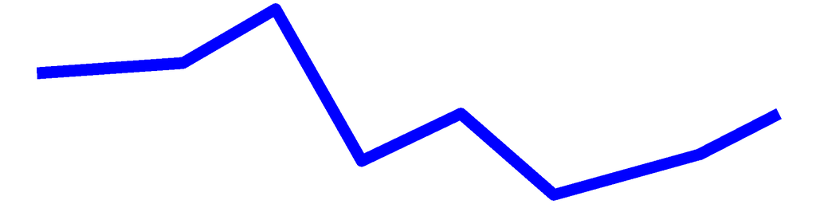

Deep TP (mg/L)

0.03

0.06

0.09

0.06

0.17

0.24

0.25

0.29

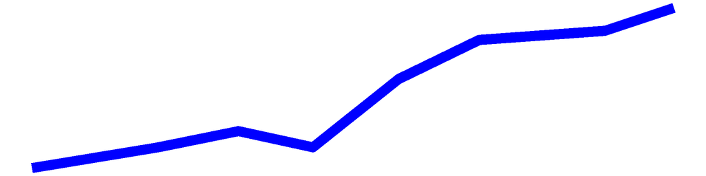

Deep TDP (mg/L)

0.01

0.01

0.02

0.03

0.04

0.02

0.05

0.07

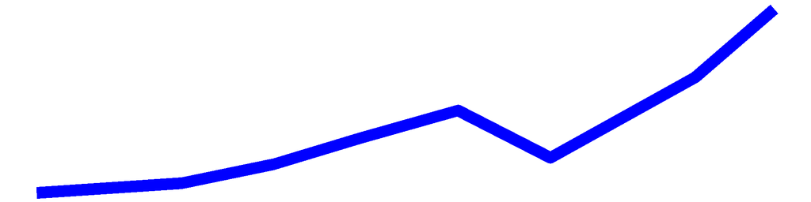

TN (mg/L)

0.59

0.45

0.22

0.35

0.65

0.31

0.54

0.38

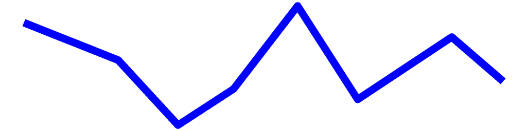

TDN (mg/L)

0.59

0.50

0.21

0.30

0.42

0.21

0.43

0.38

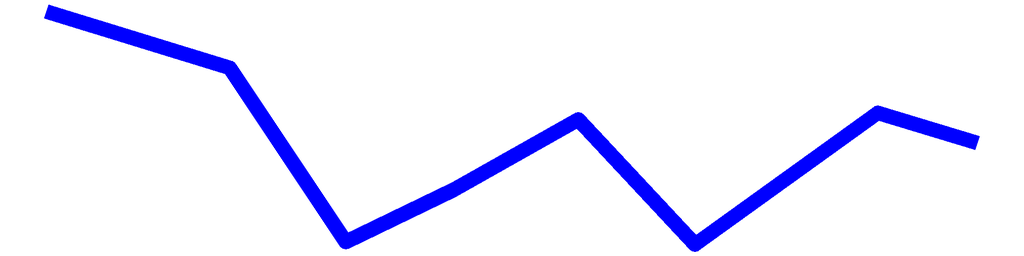

TN:TP

53.98

40.54

21.59

35.88

67.47

26.81

39.46

27.84

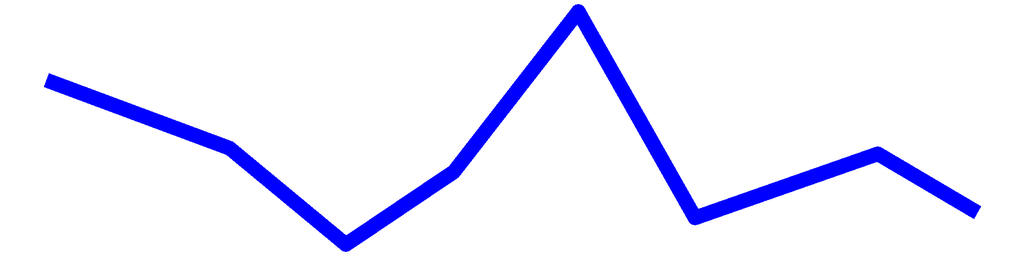

Surface NH3 (mg/L)

0.05

0.06

0.04

0.02

0.03

0.06

0.02

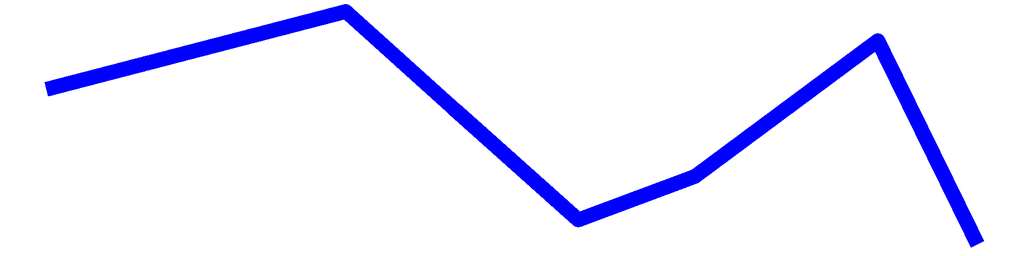

Deep NH3 (mg/L)

0.42

0.52

0.45

0.35

0.89

0.68

0.90

1.31

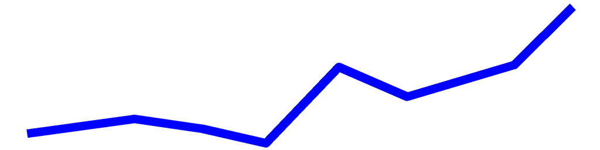

Chl.a (ug/L)

3.70

2.60

2.40

2.80

2.70

7.30

3.90

8.80

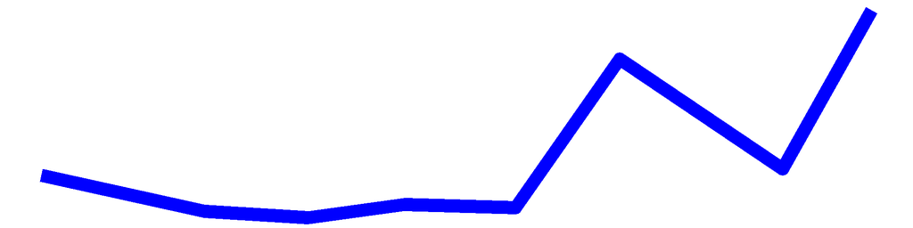

pH

7.71

8.21

7.87

7.88

7.50

8.35

7.46

7.46

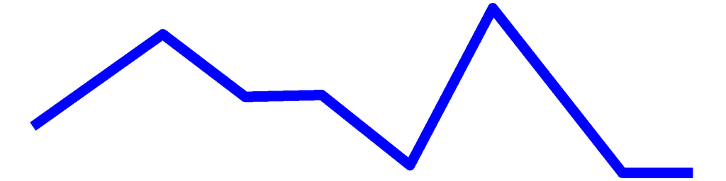

Cond (umho/cm)

162.40

139.30

142.80

115.50

155.50

165.80

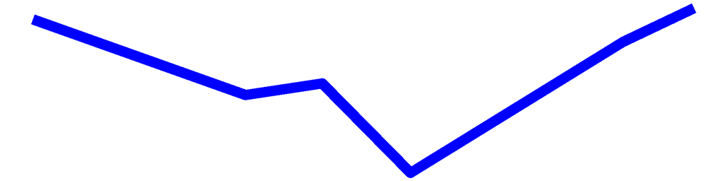

Surface Calcium (mg/L)

Bottom Calcium (mg/L)

Surface Chloride (mg/L)

17.20

Bottom Chloride (mg/L)

Upper Temp (degC)

25.00

30.00

34.00

29.00

31.00

28.00

27.00

23.00

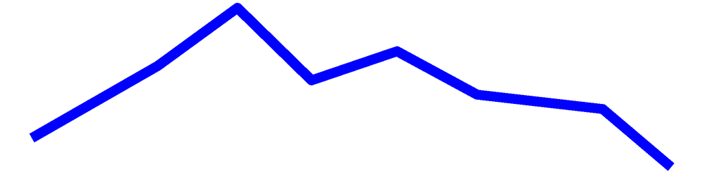

Deep Temp (degC)

13.00

14.50

14.00

14.00

14.00

15.00

15.00

12.00

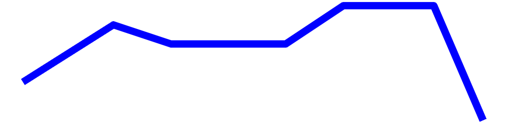

5.29

10.20

3.87

2.15

5.99

12.78

7.25

11.83

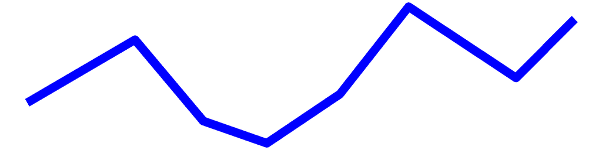

## Crooked Lake – Sampling Season Results

### HABs Status

#### Open Water Algae

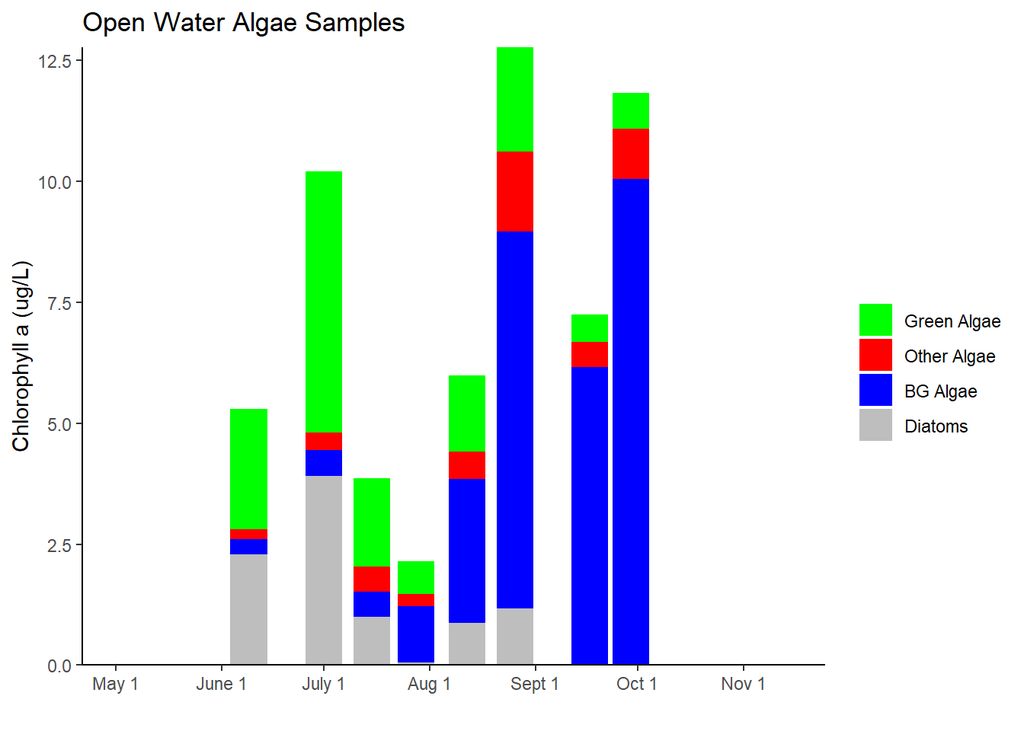

#### Shoreline Algae

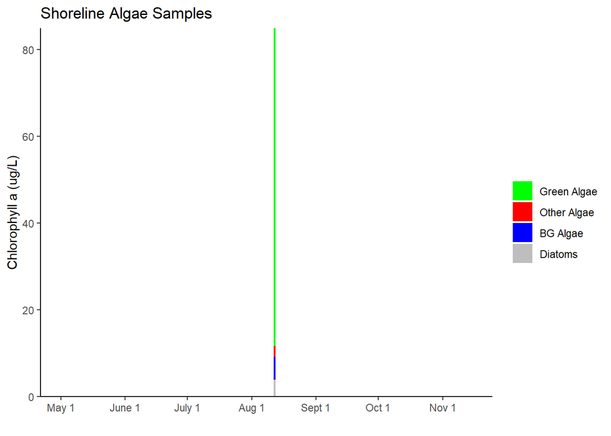

## Crooked Lake Long-Term Trend Analysis

#### Clarity

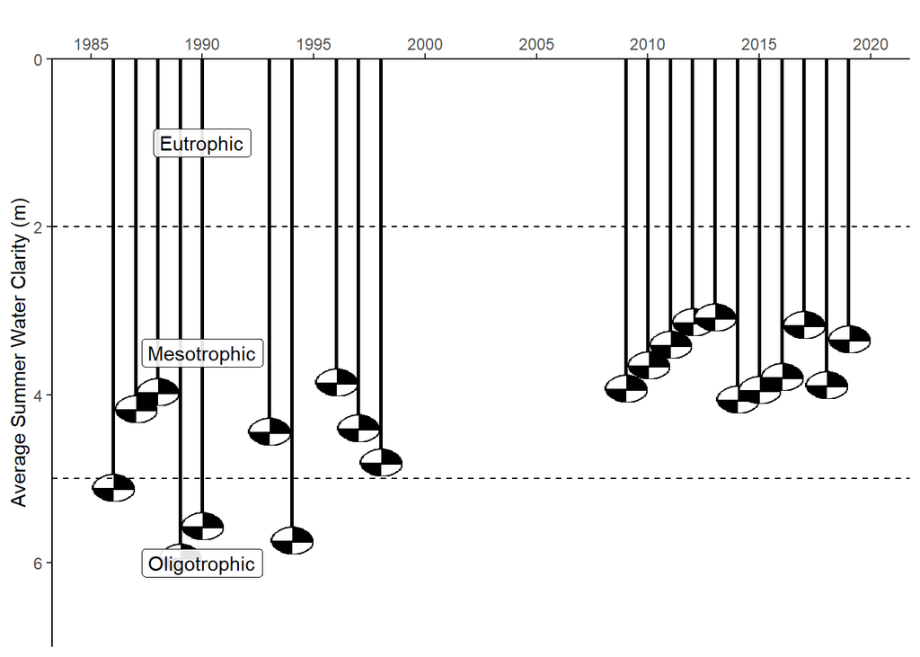

#### Chlorophyll *a*

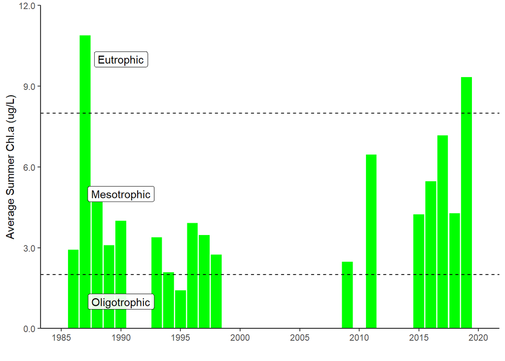

#### Surface and Deep Phosphorus

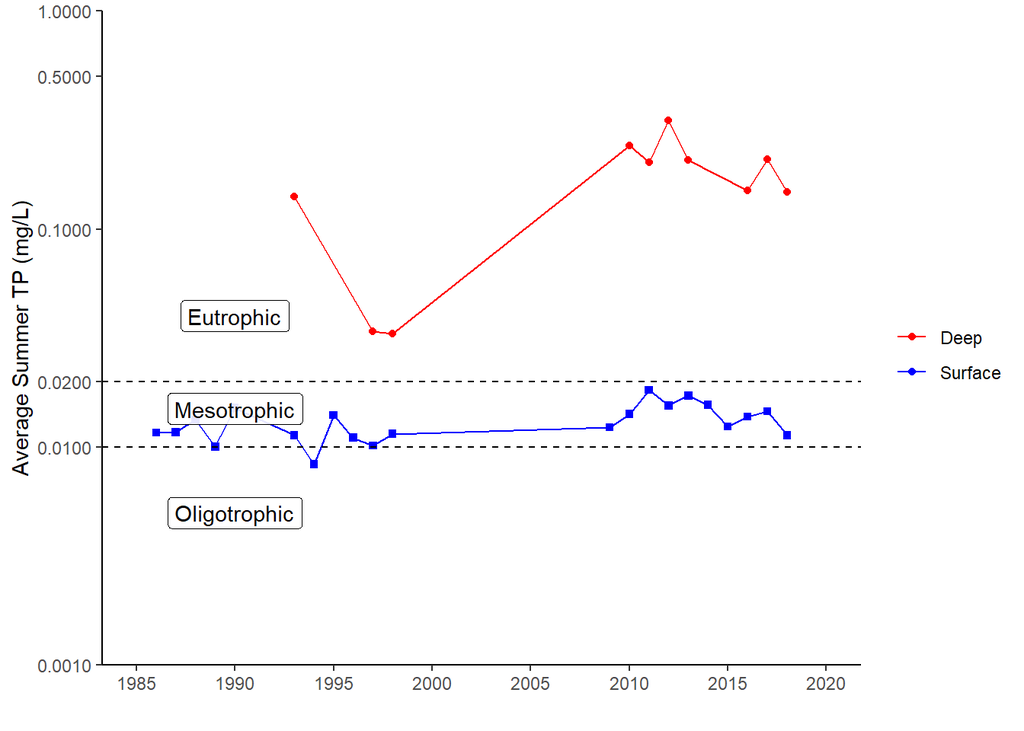

#### Nitrogen

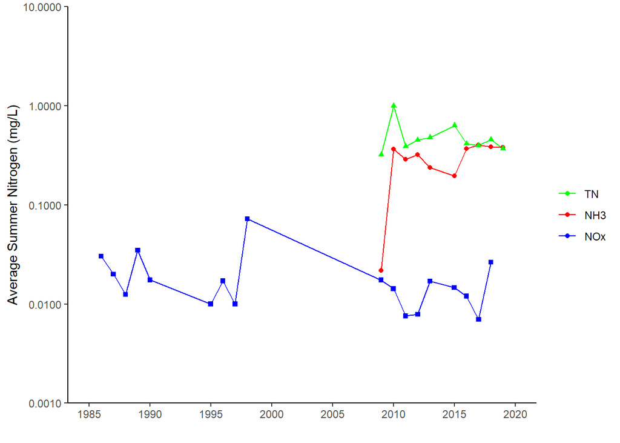

#### TN : TP

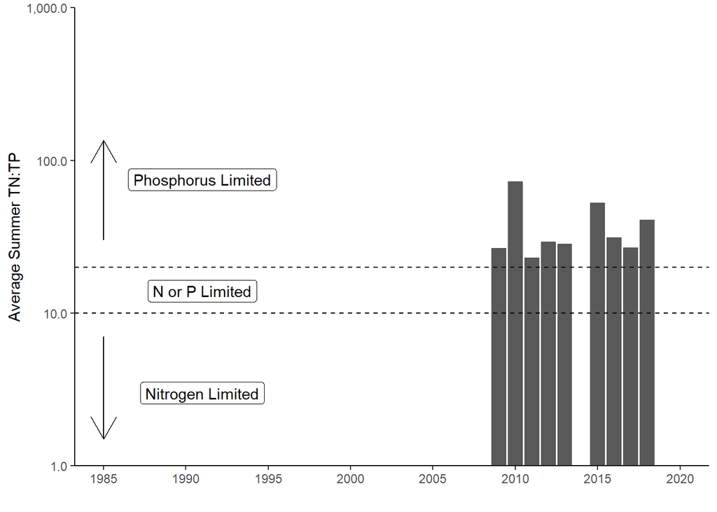

#### pH

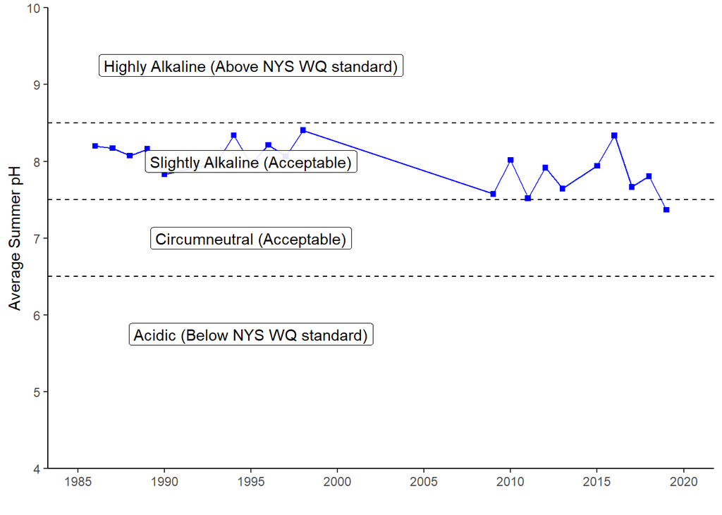

#### Specific Conductance

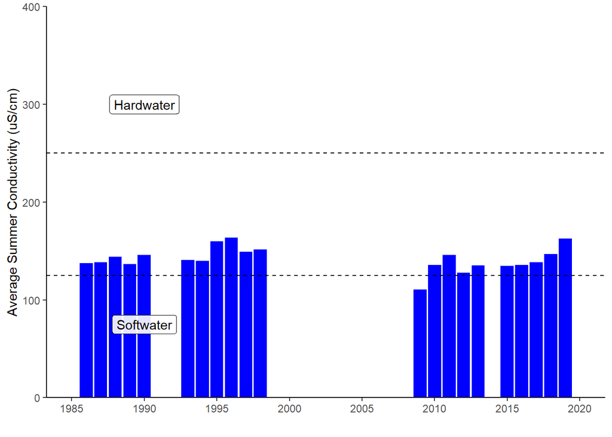

#### Calcium

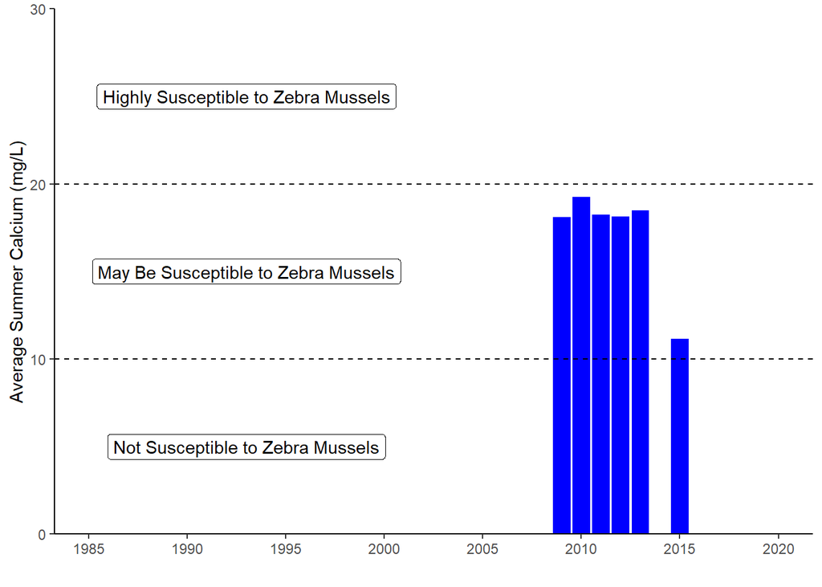

#### Chloride

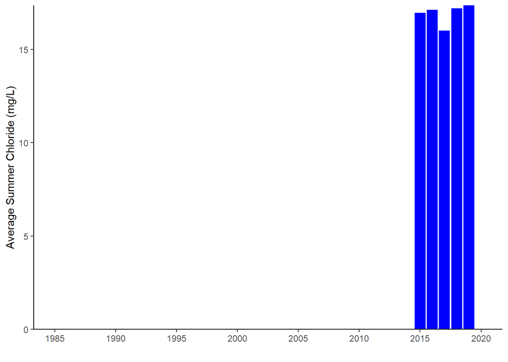

#### Color

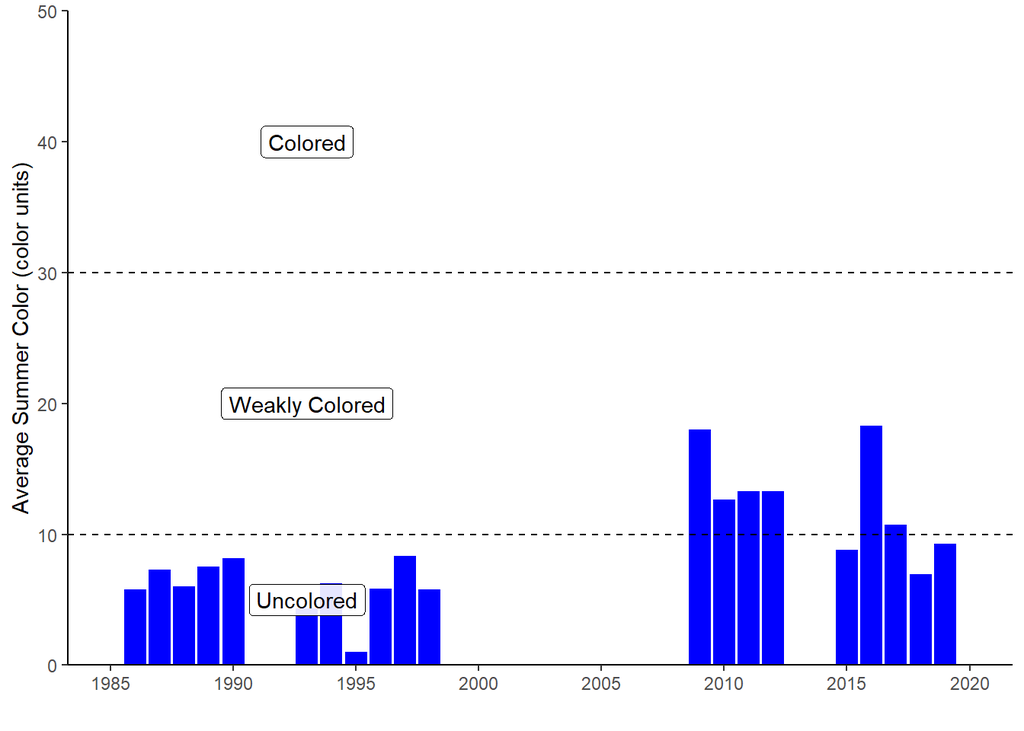

#### Surface and Deep Temperature

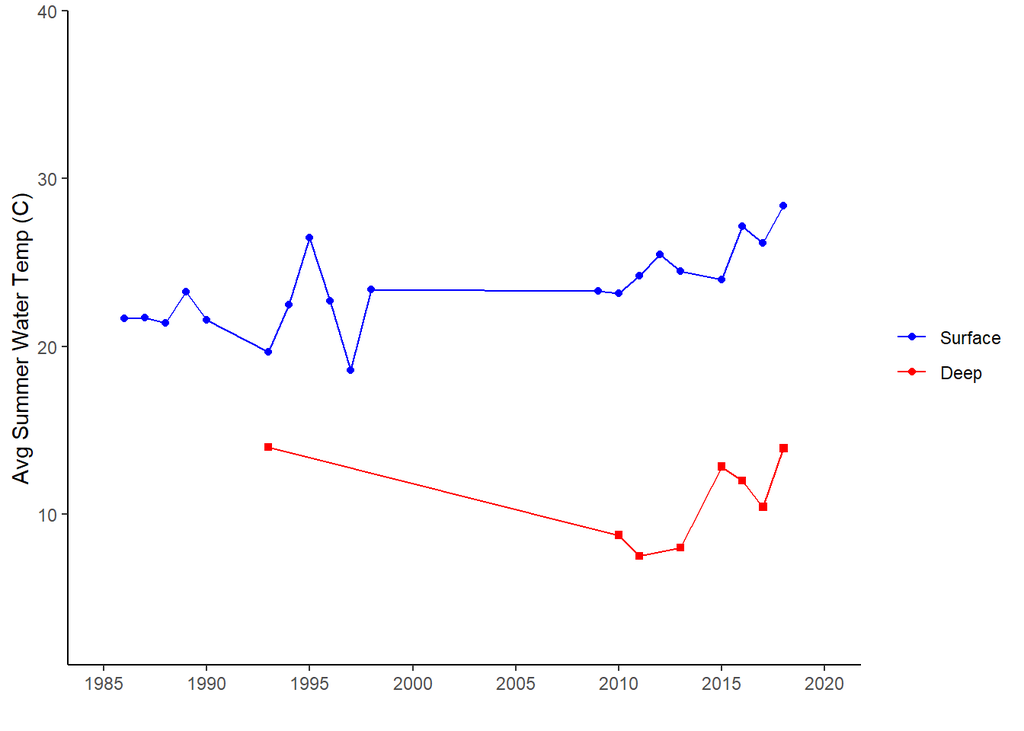

#### Lake Perception

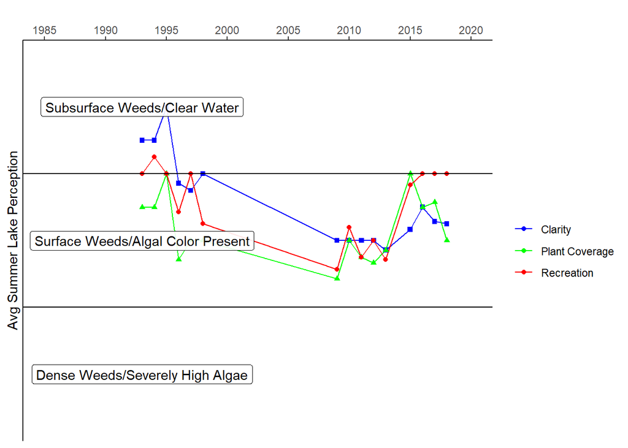

## Crooked Lake - In-Season Analysis

#### In Season Water Clarity

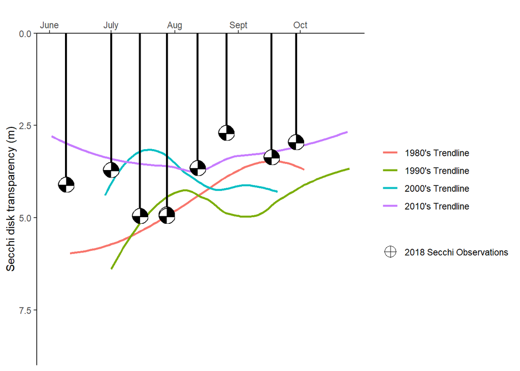

#### In Season Water Temperature

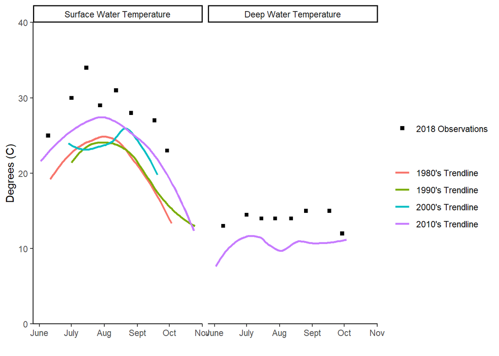